# ELA Learning Growth (City): Average annual learning growth between 3rd and 8th grade

Author

Written originally by E Gutierrez and translated to R by JP Walsh

Published

May 13, 2026

*Program for the creation of the english language arts growth metric at the city level*

Uses MEPS: the share of students attending schools where 20% or more students are in Poverty ** - Uses 2014-2019 data - Produces city level data

## Housekeeping

Read in packages for use. Set the global year to the latest education data.

```r
library(tidyverse)
library(Hmisc)
library(ipumsr)
library(reactable)
library(srvyr)
library(scales)
library(educationdata)
library(haven)
library(broom)        # For regression output processing
library(future)       # For parallel processing
library(future.apply) # For parallel apply functions
library(glue)

options(scipen = 999)
options(timeout=60*10)

# Set up parallel processing for computational efficiency
plan(multisession, workers = parallel::detectCores() - 1)


# Configuration
config <- list(
  current_year = 2020,    # Spring of school year (2019-20)
  latest_year = 2019,     # Fall of current SEDA year (2019-20)

  # Quality thresholds for learning rate estimates
  quality_thresholds = list(
    high_quality = list(min_grades = 5, min_sample = 30),      # Quality = 1
    medium_quality = list(min_grades = 4, min_sample = 30),    # Quality = 2
    low_quality = list(min_grades = 3, min_sample = 10)        # Quality = 3
  )
)


# Demographic subgroups to process
subgroups <- c("all", "wht", "blk", "hsp", "nec", "ecd", "mal", "fem")
```

Source the function `evaluate_final_data.R`.

```r
source(here::here("functions", "testing", "evaluate_final_data.R"))
```

## Import and save raw data

This first section imports and saves all of the necessary raw data for the ELA metric.

### Place crosswalk file

Read in the City crosswalk file

```r
place <- read_csv(here::here("geographic-crosswalks", "data", "place-populations.csv"))
```

Clean city names. The CCD district data inlcudes some unique city_name spellings. To confirm a match, we adjust the names in our crosswalk file.

```r
place_clean <- place %>%
  mutate(place_name = str_replace_all(place_name, " city| town| municipality| village| urban county", ""),
         city_name = case_when(place_name == "San Buenaventura (Ventura)" ~ "Ventura",
                                      place_name == "Athens-Clarke County unified government (balance)" ~ "Athens",
                                      place_name == "Augusta-Richmond County consolidated government (balance)" ~ "Augusta",
                                      place_name == "Macon-Bibb County" ~ "Macon",
                                      place_name == "Boise City" ~ "Boise",
                                      place_name == "Lexington-Fayette" ~ "Lexington",
                                      place_name == "Louisville/Jefferson County metro government (balance)" ~ "Louisville",
                                      place_name == "Nashville-Davidson metropolitan government (balance)" ~ "Nashville",
                                      place_name == "McAllen" ~ "Mcallen",
                                      place_name == "McKinney" ~ "Mckinney",
         TRUE ~ place_name),
         city_name = str_to_lower(city_name),
         geoid = paste0(state, place)) %>%
  select(-place_name, -population)
```

### CCD District Data

Download CCD district data from Urban’s Education Data Portal - School district level - Directory as topic - ccd as source - Years 2008 through the latest year - include labels

Will match leaid to SEDA data, then match city_location to city crosswalk.

```r
if(!file.exists(here::here("07_effective-public-education", "Data", "Raw", "ccd_districts.csv"))) {

  get_education_data(level = "school-districts",
                     source = "ccd",
                     topic = "directory",
                     filters = list(year = 2008:config$latest_year),
                     add_labels = TRUE) %>%
    select(year, leaid, city_location, fips) %>%
    data.table::fwrite(here::here("07_effective-public-education", "Data", "Raw", "ccd_districts.csv"))

}

education_data <- data.table::fread(here::here("07_effective-public-education", "Data", "Raw", "ccd_districts.csv")) %>%
  filter(year <= config$current_year)
```

Create a state variable in the CCD data from the leaid.

```r
education_data <- education_data %>%
  mutate(leaid = str_pad(leaid, width = 7, side = "left", pad = "0"),
         state = str_sub(leaid, 1, 2))
```

### Download SEDA

SEDA data are downloaded from Stanford’s SEDA website: https://edopportunity.org/get-the-data/seda-archive-downloads/ ** SEDA data standardize EDFacts assessments data across states and years using NAEP data **

```r
if(!file.exists(here::here("07_effective-public-education", "Data", "Raw", "seda_geodist.csv"))) {

download.file("https://stacks.stanford.edu/file/xh833nn4025/seda_geodist_long_gcs_6.0.csv", dest = here::here("07_effective-public-education", "Data", "Raw", "seda_geodist.csv"))

}

seda <- data.table::fread(here::here("07_effective-public-education", "Data", "Raw", "seda_geodist.csv"))
```

Filter for the relevant subject “rla” and define cohorts. Cohorts are defined by the year a cohort reaches 8th grade. Eg, the 2016 cohort is the cohort that is in 8th grade in 2016, in 7th grade in 2015, in 6th grade in 2014, etc

```r
seda <- seda %>%
  filter(subject == "rla") %>%
  mutate(cohort = year - grade + 8) %>%
  filter(cohort >= 2015, !is.na(cohort)) %>%
  mutate(year = year - 1)#to match to other dataset that use fall of school year
```

Combine Asian and native american students to “other”

```r
seda <- seda %>%
  mutate(tot_asmt_oth = tot_asmt_asn + tot_asmt_nam,
         temp_asn = gcs_mn_asn*tot_asmt_asn,
         temp_nam = gcs_mn_nam*tot_asmt_nam,
         gcs_mn_oth = temp_asn + temp_nam,
         gcs_mn_oth = gcs_mn_oth/tot_asmt_oth)
```

Clean the SEDA data for merge

```r
seda <- seda %>%
  rename(leaid = sedalea) %>%
  mutate(leaid = str_pad(leaid, width = 7, side = "left", pad = "0"),
         state = str_sub(leaid, 1, 2))
```

Merge to common core data to get city location. Some SEDA data matches the CCD data in certain years but not others. Group by the leaid and fill in city location for cases where the ccd data do not join.

```r
merged_education_data <- seda %>%
    left_join(education_data, by = c("leaid", "state", "year")) %>%

    # Handle districts that appear in some years but not others
    group_by(leaid) %>%
    mutate(
      # Flag districts that ever match to CCD data
      has_location = any(!is.na(city_location))
    ) %>%
    # Forward/backward fill city location within district (only for districts with location data)
    # Using tidyr::fill()
    filter(has_location) %>%
    arrange(leaid, year) %>%
    tidyr::fill(city_location, .direction = "downup") %>%
    ungroup() %>%

    # Clean city names to proper case for matching
    mutate(
      city_name = str_to_lower(city_location)
    ) %>%

    # Merge with city crosswalk to get standardized place codes
    inner_join(place_clean, by = c("city_name", "state")) %>%

    # THe earliest cohorts start in 2014
    filter(
      cohort >= 2014,
      cohort <= config$current_year
    ) %>%

    # Convert back to numeric LEAID
    mutate(leaid = as.numeric(leaid)) %>%

    select(-city_location, -has_location)
```

## Clean and Calculate Growth Estimates for each subgroup

To create the learning rates a regression of mean assessment scores is run on grade (as a continuous variable) interacted with each district in order to obtain district-specific grade slopes.

*Regressions are weighted by the number of test-takers for each year, grade, and district.

95% confidence intervals are calculated as the slope estimate plus or minus 1.96 times the standard error of the estimate.

A flag indicates how many grades are included in each estimate.

```r
calculate_learning_rates <- function(education_data, subgroups) {

  cat("Calculating learning rates by subgroup...\n")

  # Function to calculate learning rate for a single subgroup-cohort combination
  calc_subgroup_rates <- function(data, subgroup, cohort_year) {

    # Column names for this subgroup
    score_col <- glue("gcs_mn_{subgroup}")
    n_col <- glue("tot_asmt_{subgroup}")

    # Prepare data for regression
    reg_data <- data %>%
      filter(cohort == cohort_year) %>%
      select(leaid, grade, all_of(score_col), all_of(n_col)) %>%
      rename(score = !!score_col, n_students = !!n_col) %>%
      filter(!is.na(score), n_students > 0)

    if (nrow(reg_data) == 0) return(NULL)

    # Run weighted regression: score ~ grade × district
    # This gives district-specific slopes (learning rates)
    model <- lm(score ~ grade:factor(leaid) + factor(leaid),
                data = reg_data, weights = n_students)

    # Extract coefficients and standard errors
    coef_summary <- tidy(model) %>%
      filter(str_detect(term, "grade:factor\\(leaid\\)")) %>%
      mutate(
        leaid = as.numeric(str_extract(term, "(?<=leaid\\))\\d+"))
      ) %>%
      select(leaid, estimate, std.error) %>%
      rename(learning_rate = estimate, se = std.error)

    # Calculate quality metrics for each district
    quality_metrics <- reg_data %>%
      group_by(leaid) %>%
      summarise(
        num_grades_included = n(),
        min_sample_size = min(n_students, na.rm = TRUE),
        .groups = "drop"
      )

    # Combine results
    results <- coef_summary %>%
      left_join(quality_metrics, by = "leaid") %>%
      mutate(
        cohort = cohort_year,
        subgroup = subgroup,

        # Calculate confidence intervals
        learning_rate_lb = learning_rate - 1.96 * se,
        learning_rate_ub = learning_rate + 1.96 * se,

        # Assign quality flags based on sample size and grade coverage
        learning_rate_quality = case_when(
          (num_grades_included >= 5 & min_sample_size >= 30) ~ 1L,  # High quality
          (num_grades_included >= 4 & min_sample_size >= 30) ~ 2L,  # Medium quality
          (!is.na(learning_rate)) ~ 3L,                             # Low quality
          TRUE ~ NA_integer_
        ),

        # Remove false zeros (artifact of regression procedure)
        learning_rate = ifelse(learning_rate == 0 & learning_rate_lb == 0 & learning_rate_ub == 0,
                               NA_real_, learning_rate),
        learning_rate_lb = ifelse(is.na(learning_rate), NA_real_, learning_rate_lb),
        learning_rate_ub = ifelse(is.na(learning_rate), NA_real_, learning_rate_ub),
        learning_rate_quality = ifelse(is.na(learning_rate), NA_integer_, learning_rate_quality)
      ) %>%

      select(cohort, leaid, subgroup, learning_rate, learning_rate_lb,
             learning_rate_ub, learning_rate_quality)

    return(results)
  }

  # Calculate learning rates for all subgroups and cohorts
  # Use parallel processing for efficiency
  all_combinations <- expand_grid(
    subgroup = subgroups,
    cohort = unique(education_data$cohort)
  )

  #Increase future max limit

  oopts <- options(future.globals.maxSize = 1.0 * 1e9)  ## 1.0 GB
  on.exit(options(oopts))

  learning_rates <- furrr::future_map2_dfr(
    all_combinations$subgroup,
    all_combinations$cohort,
    ~ calc_subgroup_rates(education_data, .x, .y),
    .progress = TRUE
  )

cat(glue("✓ Calculated learning rates for {format(nrow(learning_rates), big.mark = ",")} district-subgroup-cohort combinations\n"))

  return(learning_rates)
}

# Calculate learning rates
district_learning_rates <- calculate_learning_rates(merged_education_data, subgroups)
```

```
Calculating learning rates by subgroup...
✓ Calculated learning rates for 32875 district-subgroup-cohort combinations
```

## City-Level Aggregation

Aggregate district-level learning rates to city level using enrollment weighting.

```r
aggregate_to_cities <- function(education_data, learning_rates, city_crosswalk) {

  cat("Aggregating learning rates to city level...\n")

  # Get enrollment weights for aggregation
  enrollment_weights <- education_data %>%
    group_by(leaid, cohort, city_name, state, place) %>%
    summarise(
      across(starts_with("tot_asmt_"), sum, na.rm = TRUE),
      .groups = "drop"
    )

  # Function to aggregate one subgroup at a time
  aggregate_subgroup <- function(subgroup_name) {

    n_col <- glue("tot_asmt_{subgroup_name}")

    # Merge learning rates with enrollment weights
    subgroup_data <- learning_rates %>%
      filter(subgroup == subgroup_name) %>%
      left_join(enrollment_weights, by = c("leaid", "cohort")) %>%
      filter(!is.na(.data[[n_col]]), .data[[n_col]] > 0)

    # Aggregate to city level using enrollment weighting
    city_aggregated <- subgroup_data %>%
      group_by(city_name, state, place, cohort) %>%
      summarise(
        learning_rate = weighted.mean(learning_rate, .data[[n_col]], na.rm = TRUE),
        learning_rate_lb = weighted.mean(learning_rate_lb, .data[[n_col]], na.rm = TRUE),
        learning_rate_ub = weighted.mean(learning_rate_ub, .data[[n_col]], na.rm = TRUE),
        learning_rate_quality = round(weighted.mean(learning_rate_quality, .data[[n_col]], na.rm = TRUE)),
        .groups = "drop"
      ) %>%
      mutate(subgroup = subgroup_name) %>%
      rename(year = cohort) %>%
      # Adjust year to reflect fall of academic year
      mutate(year = year - 1)

    return(city_aggregated)
  }

  # Aggregate all subgroups and combine
  city_results <- map_dfr(subgroups, aggregate_subgroup)

  #cat(glue("✓ Aggregated to {length(unique(city_results$city_name), big.mark = ",")} cities\n"))

  return(city_results)
}

# Aggregate to city level
city_learning_rates <- aggregate_to_cities(merged_education_data, district_learning_rates, city_crosswalk)
```

```
Aggregating learning rates to city level...
```

## Data Quality Assessment

Evaluate the quality and coverage of the learning rate estimates.

```r
assess_data_quality <- function(city_data) {

  cat("=== DATA QUALITY ASSESSMENT ===\n\n")

  # Overall summary statistics by quality level
  cat("Learning Rate Distributions by Quality Level:\n")
  quality_summary <- city_data %>%
    filter(subgroup == "all") %>%
    group_by(learning_rate_quality) %>%
    summarise(
      n_obs = n(),
      mean_rate = mean(learning_rate, na.rm = TRUE),
      median_rate = median(learning_rate, na.rm = TRUE),
      sd_rate = sd(learning_rate, na.rm = TRUE),
      .groups = "drop"
    )

  print(quality_summary)
  cat("\n")

  # Coverage by year and subgroup
  cat("Data Coverage by Year and Subgroup:\n")
  coverage <- city_data %>%
    group_by(year, subgroup) %>%
    summarise(
      total_cities = n(),
      cities_with_data = sum(!is.na(learning_rate)),
      pct_coverage = round(100 * cities_with_data / total_cities, 1),
      .groups = "drop"
    ) %>%
    pivot_wider(names_from = subgroup, values_from = c(cities_with_data, pct_coverage))

  print(coverage)
  cat("\n")

  # Check for logical consistency in confidence intervals
  cat("Confidence Interval Consistency Checks:\n")
  ci_issues <- city_data %>%
    filter(!is.na(learning_rate)) %>%
    summarise(
      below_lower_bound = sum(learning_rate < learning_rate_lb, na.rm = TRUE),
      above_upper_bound = sum(learning_rate > learning_rate_ub, na.rm = TRUE)
    )

  cat(glue("• Estimates below lower bound: {ci_issues$below_lower_bound}\n"))
  cat(glue("• Estimates above upper bound: {ci_issues$above_upper_bound}\n\n"))

  # Quality flag completeness
  cat("Quality Flag Assessment:\n")
  quality_flags <- city_data %>%
    summarise(
      total_observations = n(),
      missing_quality_flags = sum(is.na(learning_rate_quality)),
      quality_flag_when_missing_rate = sum(is.na(learning_rate) & !is.na(learning_rate_quality))
    )

  cat(glue("• Missing quality flags: {quality_flags$missing_quality_flags}\n"))
  cat(glue("• Quality flags when rate is missing: {quality_flags$quality_flag_when_missing_rate}\n\n"))

  return(invisible(city_data))
}

# Assess data quality
final_data <- assess_data_quality(city_learning_rates)
```

```
=== DATA QUALITY ASSESSMENT ===

Learning Rate Distributions by Quality Level:
# A tibble: 2 x 5
  learning_rate_quality n_obs mean_rate median_rate sd_rate
                  <dbl> <int>     <dbl>       <dbl>   <dbl>
1                     1  2459     0.987       0.988   0.160
2                   NaN    17   NaN          NA      NA

Data Coverage by Year and Subgroup:
# A tibble: 28 x 18
    year total_cities cities_with_data_all cities_with_data_blk
   <dbl>        <int>                <int>                <int>
 1  2014          414                  414                   NA
 2  2014          386                   NA                  379
 3  2014          410                   NA                   NA
 4  2014          413                   NA                   NA
 5  2014          411                   NA                   NA
 6  2015          414                  414                   NA
 7  2015          378                   NA                  375
 8  2015          411                   NA                   NA
 9  2015          413                   NA                   NA
10  2016          416                  416                   NA
# i 18 more rows
# i 14 more variables: cities_with_data_ecd <int>, cities_with_data_fem <int>,
#   cities_with_data_hsp <int>, cities_with_data_mal <int>,
#   cities_with_data_nec <int>, cities_with_data_wht <int>,
#   pct_coverage_all <dbl>, pct_coverage_blk <dbl>, pct_coverage_ecd <dbl>,
#   pct_coverage_fem <dbl>, pct_coverage_hsp <dbl>, pct_coverage_mal <dbl>,
#   pct_coverage_nec <dbl>, pct_coverage_wht <dbl>

Confidence Interval Consistency Checks:
• Estimates below lower bound: 0• Estimates above upper bound: 0
Quality Flag Assessment:
• Missing quality flags: 213• Quality flags when rate is missing: 0
```

## Data Visualization

Create diagnostic visualizations to understand the distribution and quality of learning rate estimates.

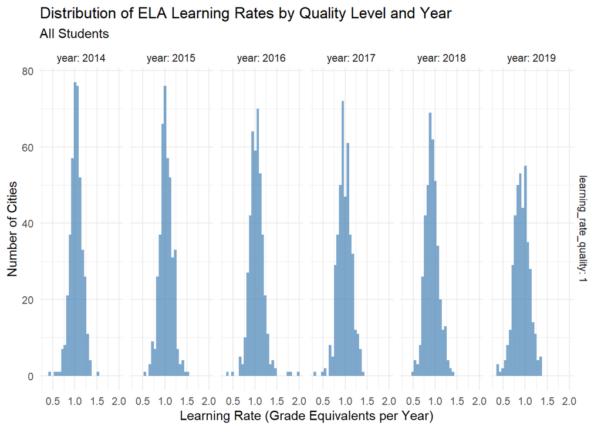

```r
create_diagnostic_plots <- function(city_data) {

  # Distribution of learning rates by quality level for all students
  p1 <- city_data %>%
    filter(subgroup == "all", !is.na(learning_rate)) %>%
    ggplot(aes(x = learning_rate)) +
    geom_histogram(bins = 30, alpha = 0.7, fill = "steelblue") +
    facet_grid(learning_rate_quality ~ year, labeller = label_both) +
    labs(
      title = "Distribution of ELA Learning Rates by Quality Level and Year",
      subtitle = "All Students",
      x = "Learning Rate (Grade Equivalents per Year)",
      y = "Number of Cities"
    ) +
    theme_minimal()

  # Learning rates by demographic subgroup
  p2 <- city_data %>%
    filter(!is.na(learning_rate), year == 2019) %>%
    ggplot(aes(x = learning_rate, fill = subgroup)) +
    geom_density(alpha = 0.6) +
    facet_wrap(~ subgroup, scales = "free_y") +
    labs(
      title = "Learning Rate Distributions by Demographic Subgroup",
      subtitle = glue("Most Recent Year: {max(city_data$year, na.rm = TRUE)}"),
      x = "Learning Rate (Grade Equivalents per Year)",
      y = "Density"
    ) +
    theme_minimal() +
    theme(legend.position = "none")

  # Quality distribution over time
  p3 <- city_data %>%
    filter(subgroup == "all", year != 2021) %>%
    count(year, learning_rate_quality) %>%
    ggplot(aes(x = factor(year), y = n, fill = factor(learning_rate_quality))) +
    geom_col(position = "stack") +
    labs(
      title = "Data Quality Distribution Over Time",
      subtitle = "All Students",
      x = "Year",
      y = "Number of Cities",
      fill = "Quality Level"
    ) +
    scale_fill_manual(
      values = c("1" = "#2E8B57", "2" = "#FFD700", "3" = "#CD5C5C"),
      labels = c("1" = "High", "2" = "Medium", "3" = "Low"),
      na.value = "grey80"
    ) +
    theme_minimal()

  # Return plots as a list
  return(list(
    quality_by_year = p1,
    subgroup_distributions = p2,
    quality_over_time = p3
  ))
}

# Generate diagnostic plots
plots <- create_diagnostic_plots(final_data)

# Display plots (uncomment to show)
plots$quality_by_year
```

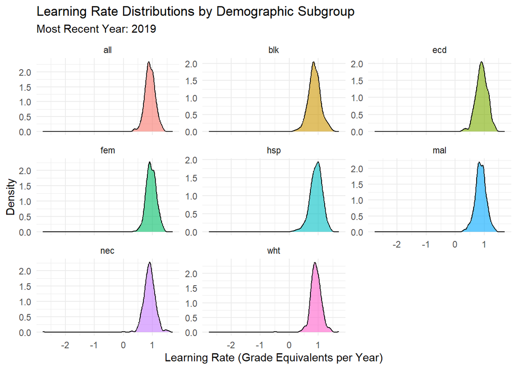

```r
plots$subgroup_distributions
```

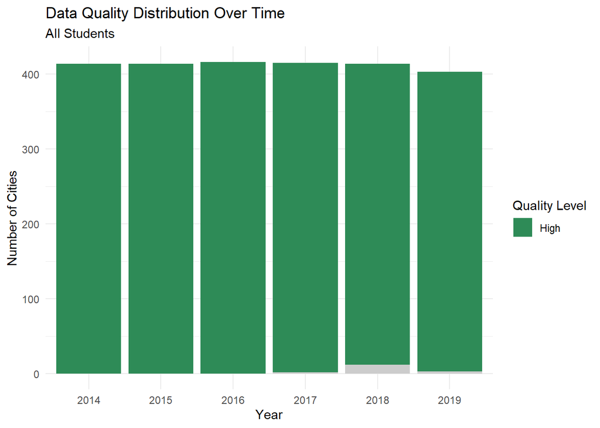

```r
plots$quality_over_time
```

Create rows for all subgroups for all base places in the data.

```r
seda_all_places <-
  left_join(
    place_clean %>% rename(year_join = year) %>%
      filter(year_join %in% c(2015:2020)),
    final_data %>% mutate(year_join = year + 1),
    by = c("year_join", "place", "state")
  ) %>%
  expand(year_join, geoid, subgroup) %>%
  filter(!is.na(subgroup), !is.na(year_join)) %>%
   mutate(state = str_sub(geoid, 1, 2),
         place = str_sub(geoid, 3, 7))

final_data <- left_join(
  seda_all_places,
  final_data %>% mutate(year_join = year + 1),
   by = c("year_join", "place", "state", "subgroup")
) %>%
  select(-year) %>%
  mutate(year = year_join - 1)
```

## Data Export

Format the data long with subgroup titles

```r
long_format <- final_data %>%

    # Create proper subgroup labels and categories
    mutate(
      subgroup_type = case_when(
        subgroup == "all" ~ "all",
        subgroup %in% c("wht", "blk", "hsp") ~ "race-ethnicity",
        subgroup %in% c("mal", "fem") ~ "gender",
        subgroup %in% c("ecd", "nec") ~ "income",
        TRUE ~ "other"
      ),

      subgroup = case_when(
        subgroup == "all" ~ "All",
        subgroup == "wht" ~ "White, Non-Hispanic",
        subgroup == "blk" ~ "Black, Non-Hispanic",
        subgroup == "hsp" ~ "Hispanic",
        subgroup == "mal" ~ "Male",
        subgroup == "fem" ~ "Female",
        subgroup == "ecd" ~ "Economically Disadvantaged",
        subgroup == "nec" ~ "Not Economically Disadvantaged",
        TRUE ~ subgroup
      )
    ) %>%

    # Final column ordering
    select(year, state, place, subgroup_type, subgroup,
           learning_rate, learning_rate_lb, learning_rate_ub, learning_rate_quality) %>%

    arrange(desc(year), state, place, subgroup_type, subgroup)
```

Run final evaluations and Write out all files

```r
all <- long_format %>%
  filter(subgroup_type %in% c("all")) %>%
  select(-subgroup_type, -subgroup)

evaluate_final_data(exp_form_path = "10a_final-evaluation/evaluation_form_ela_overall_place.csv",
                data = all,  geography = "place",
                subgroups = FALSE, confidence_intervals = TRUE)
```

```
[1] "This data passes all tests!"
```

```r
data.table::fwrite(all, here::here("07_effective-public-education", "Data", "Final", "seda_all_city.csv"))
```

Test and write out subgroup files

```r
race_eth <- long_format %>%
  filter(subgroup_type %in% c("all", "race-ethnicity"))

evaluate_final_data(exp_form_path = "10a_final-evaluation/evaluation_form_ela_race_ethnicity_place.csv",
                data = race_eth,  geography = "place",
                subgroups = TRUE, confidence_intervals = TRUE)
```

```
[1] "This data passes all tests!"
```

```r
data.table::fwrite(race_eth, here::here("07_effective-public-education", "Data", "Final", "seda_race_ethnicity_all_city.csv"))

gender <- long_format %>%
  filter(subgroup_type %in% c("all", "gender"))

evaluate_final_data(exp_form_path = "10a_final-evaluation/evaluation_form_ela_gender_place.csv",
                data = gender,  geography = "place",
                subgroups = TRUE, confidence_intervals = TRUE)
```

```
[1] "This data passes all tests!"
```

```r
data.table::fwrite(gender, here::here("07_effective-public-education", "Data", "Final", "seda_gender_all_city.csv"))

income <- long_format %>%
  filter(subgroup_type %in% c("all", "income"))

evaluate_final_data(exp_form_path = "10a_final-evaluation/evaluation_form_ela_income_place.csv",
                data = income,  geography = "place",
                subgroups = TRUE, confidence_intervals = TRUE)
```

```
[1] "This data passes all tests!"
```

```r
data.table::fwrite(income, here::here("07_effective-public-education", "Data", "Final", "seda_income_all_city.csv"))
```